# Personal_Loan_Project

## Problem Statement

### Context

AllLife Bank is a US bank that has a growing customer base. The majority of these customers are liability customers (depositors) with varying sizes of deposits. The number of customers who are also borrowers (asset customers) is quite small, and the bank is interested in expanding this base rapidly to bring in more loan business and in the process, earn more through the interest on loans. In particular, the management wants to explore ways of converting its liability customers to personal loan customers (while retaining them as depositors).

A campaign that the bank ran last year for liability customers showed a healthy conversion rate of over 9% success. This has encouraged the retail marketing department to devise campaigns with better target marketing to increase the success ratio.

You as a Data scientist at AllLife bank have to build a model that will help the marketing department to identify the potential customers who have a higher probability of purchasing the loan.

### Objective

To predict whether a liability customer will buy personal loans, to understand which customer attributes are most significant in driving purchases, and identify which segment of customers to target more.

### Data Dictionary

- `ID`: Customer ID
- `Age`: Customer’s age in completed years
- `Experience`: #years of professional experience
- `Income`: Annual income of the customer (in thousand dollars)
- `ZIP Code`: Home Address ZIP code.
- `Family`: the Family size of the customer
- `CCAvg`: Average spending on credit cards per month (in thousand dollars)
- `Education`: Education Level. 1: Undergrad; 2: Graduate;3: Advanced/Professional
- `Mortgage`: Value of house mortgage if any. (in thousand dollars)
- `Personal_Loan`: Did this customer accept the personal loan offered in the last campaign? (0: No, 1: Yes)
- `Securities_Account`: Does the customer have securities account with the bank? (0: No, 1: Yes)
- `CD_Account`: Does the customer have a certificate of deposit (CD) account with the bank? (0: No, 1: Yes)
- `Online`: Do customers use internet banking facilities? (0: No, 1: Yes)
- `CreditCard`: Does the customer use a credit card issued by any other Bank (excluding All life Bank)? (0: No, 1: Yes)

## Importing necessary libraries

```python
# Installing the libraries with the specified version.
!pip install numpy==1.25.2 pandas==1.5.3 matplotlib==3.7.1 seaborn==0.13.1 scikit-learn==1.2.2 sklearn-pandas==2.2.0 -q --user pip
!pip uninstall uszipcode -y
!pip install uszipcode==0.2.6 --no-cache-dir
```

**Note**:

1. After running the above cell, kindly restart the notebook kernel (for Jupyter Notebook) or runtime (for Google Colab), write the relevant code for the project from the next cell, and run all cells sequentially from the next cell.
2. On executing the above line of code, you might see a warning regarding package dependencies. This error message can be ignored as the above code ensures that all necessary libraries and their dependencies are maintained to successfully execute the code in this notebook.

```python
#loading dataset
import pandas as pd
import numpy as np

#visualisation
import matplotlib.pyplot as plt
import seaborn as sns
import plotly
import plotly.graph_objects as go
import plotly.offline as pyo
from plotly.offline import iplot

# data preprocessing
from sklearn.preprocessing import StandardScaler

# data splitting
from sklearn.model_selection import train_test_split

# data modeling
from sklearn.metrics import confusion_matrix,accuracy_score,roc_curve,classification_report
from sklearn.linear_model import LogisticRegression
from sklearn.tree import DecisionTreeClassifier
from sklearn import tree
from sklearn.model_selection import GridSearchCV

# Mondel performance
from sklearn import metrics
from sklearn.metrics import f1_score,accuracy_score, recall_score, precision_score, roc_auc_score, roc_curve, confusion_matrix, precision_recall_curve
import scipy.stats as stats

# Zip Code
from uszipcode import SearchEngine
search = SearchEngine(simple_zipcode=True)

# to suppress unnecessary warnings
import warnings
warnings.filterwarnings("ignore")
```

## Loading the dataset

```python
#uncomment and run the following line if using Google Colab
from google.colab import drive
drive.mount('/content/drive')

# loading data into a pandas dataframe
df = pd.read_csv("/content/drive/My Drive/Loan_Modelling.csv")
data = df.copy()
```

## Data Overview

- Observations
- Sanity checks

```python
# Display the first 5 rows of the DataFrame
data.head(5)
```

|  | ID | Age | Experience | Income | ZIPCode | Family | CCAvg | Education | Mortgage | Personal_Loan | Securities_Account | CD_Account | Online | CreditCard |
| --- | --- | --- | --- | --- | --- | --- | --- | --- | --- | --- | --- | --- | --- | --- |
| 0 | 1 | 25 | 1 | 49 | 91107 | 4 | 1.6 | 1 | 0 | 0 | 1 | 0 | 0 | 0 |
| 1 | 2 | 45 | 19 | 34 | 90089 | 3 | 1.5 | 1 | 0 | 0 | 1 | 0 | 0 | 0 |
| 2 | 3 | 39 | 15 | 11 | 94720 | 1 | 1.0 | 1 | 0 | 0 | 0 | 0 | 0 | 0 |
| 3 | 4 | 35 | 9 | 100 | 94112 | 1 | 2.7 | 2 | 0 | 0 | 0 | 0 | 0 | 0 |
| 4 | 5 | 35 | 8 | 45 | 91330 | 4 | 1.0 | 2 | 0 | 0 | 0 | 0 | 0 | 1 |

```python
# Returns a tuple with the number of rows and columns in the DataFrame (rows, columns)
data.shape
```

```
(5000, 14)
```

```python
data.info()
```

```
<class 'pandas.core.frame.DataFrame'>
RangeIndex: 5000 entries, 0 to 4999
Data columns (total 14 columns):
 #   Column              Non-Null Count  Dtype
---  ------              --------------  -----
 0   ID                  5000 non-null   int64
 1   Age                 5000 non-null   int64
 2   Experience          5000 non-null   int64
 3   Income              5000 non-null   int64
 4   ZIPCode             5000 non-null   int64
 5   Family              5000 non-null   int64
 6   CCAvg               5000 non-null   float64
 7   Education           5000 non-null   int64
 8   Mortgage            5000 non-null   int64
 9   Personal_Loan       5000 non-null   int64
 10  Securities_Account  5000 non-null   int64
 11  CD_Account          5000 non-null   int64
 12  Online              5000 non-null   int64
 13  CreditCard          5000 non-null   int64
dtypes: float64(1), int64(13)
memory usage: 547.0 KB
```

```python
data.isnull().sum()
```

|  | 0 |
| --- | --- |
| ID | 0 |
| Age | 0 |
| Experience | 0 |
| Income | 0 |
| ZIPCode | 0 |
| Family | 0 |
| CCAvg | 0 |
| Education | 0 |
| Mortgage | 0 |
| Personal_Loan | 0 |
| Securities_Account | 0 |
| CD_Account | 0 |
| Online | 0 |
| CreditCard | 0 |

**dtype:** int64

```python
data.duplicated().sum()
```

```
np.int64(0)
```

```python
data.describe()
```

|  | ID | Age | Experience | Income | ZIPCode | Family | CCAvg | Education | Mortgage | Personal_Loan | Securities_Account | CD_Account | Online | CreditCard |
| --- | --- | --- | --- | --- | --- | --- | --- | --- | --- | --- | --- | --- | --- | --- |
| count | 5000.000000 | 5000.000000 | 5000.000000 | 5000.000000 | 5000.000000 | 5000.000000 | 5000.000000 | 5000.000000 | 5000.000000 | 5000.000000 | 5000.000000 | 5000.00000 | 5000.000000 | 5000.000000 |
| mean | 2500.500000 | 45.338400 | 20.104600 | 73.774200 | 93169.257000 | 2.396400 | 1.937938 | 1.881000 | 56.498800 | 0.096000 | 0.104400 | 0.06040 | 0.596800 | 0.294000 |
| std | 1443.520003 | 11.463166 | 11.467954 | 46.033729 | 1759.455086 | 1.147663 | 1.747659 | 0.839869 | 101.713802 | 0.294621 | 0.305809 | 0.23825 | 0.490589 | 0.455637 |
| min | 1.000000 | 23.000000 | -3.000000 | 8.000000 | 90005.000000 | 1.000000 | 0.000000 | 1.000000 | 0.000000 | 0.000000 | 0.000000 | 0.00000 | 0.000000 | 0.000000 |
| 25% | 1250.750000 | 35.000000 | 10.000000 | 39.000000 | 91911.000000 | 1.000000 | 0.700000 | 1.000000 | 0.000000 | 0.000000 | 0.000000 | 0.00000 | 0.000000 | 0.000000 |
| 50% | 2500.500000 | 45.000000 | 20.000000 | 64.000000 | 93437.000000 | 2.000000 | 1.500000 | 2.000000 | 0.000000 | 0.000000 | 0.000000 | 0.00000 | 1.000000 | 0.000000 |
| 75% | 3750.250000 | 55.000000 | 30.000000 | 98.000000 | 94608.000000 | 3.000000 | 2.500000 | 3.000000 | 101.000000 | 0.000000 | 0.000000 | 0.00000 | 1.000000 | 1.000000 |
| max | 5000.000000 | 67.000000 | 43.000000 | 224.000000 | 96651.000000 | 4.000000 | 10.000000 | 3.000000 | 635.000000 | 1.000000 | 1.000000 | 1.00000 | 1.000000 | 1.000000 |

**Observations**:

- The dataset contains 5,000 rows and 14 columns.
- Out of the 14 columns, 13 are integers, while only the CCAvg column is a float.
- No duplicate values are present.
- No missing values (NaNs) found.
- The Experience column contains negative values, which are not logically possible. These values need to be identified and handled appropriately.

## Exploratory Data Analysis.

- EDA is an important part of any project involving data.
- It is important to investigate and understand the data better before building a model with it.
- A few questions have been mentioned below which will help you approach the analysis in the right manner and generate insights from the data.
- A thorough analysis of the data, in addition to the questions mentioned below, should be done.

**Questions**:

1. What is the distribution of mortgage attribute? Are there any noticeable patterns or outliers in the distribution?
2. How many customers have credit cards?
3. What are the attributes that have a strong correlation with the target attribute (personal loan)?
4. How does a customer's interest in purchasing a loan vary with their age?
5. How does a customer's interest in purchasing a loan vary with their education?

**Answers:**

The mortgage distribution is right-skewed, meaning most customers have relatively low mortgage amounts, while a small group has significantly higher values. There are several outliers, which suggests that a few customers have much larger mortgages compared to the majority.

When looking at patterns and outliers, we can see that outliers exist in multiple attributes, especially mortgage and income. Another issue is that the experience attribute contains negative values, which doesn’t make sense and should be corrected. Additionally, credit card spending (CCAvg) is highly skewed, with a few customers spending much more than the rest.

As for the factors that influence personal loan approvals, some key attributes stand out:

- Income – Higher-income individuals are more likely to take a personal loan.
- Credit Card Spending (CCAvg) – Customers who spend more on credit cards tend to accept loans more often.
- Education Level – Those with higher education levels (graduate or advanced degrees) show a greater tendency to take loans.
- CD Account Ownership – Customers who have Certificate of Deposit (CD) accounts are more likely to accept loan offers.

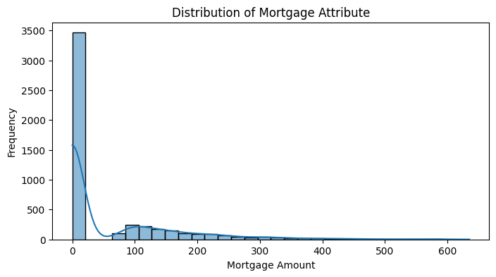

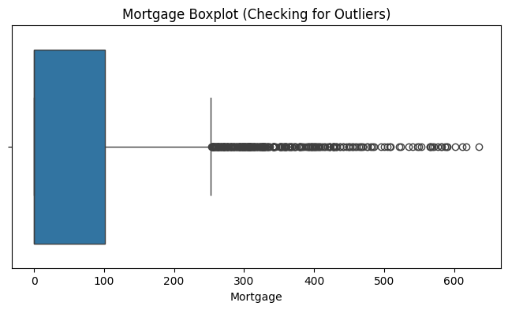

```python
# 1. Distribution of the mortgage attribute
plt.figure(figsize=(8, 4))
sns.histplot(data['Mortgage'], kde=True, bins=30)
plt.title('Distribution of Mortgage Attribute')
plt.xlabel('Mortgage Amount')
plt.ylabel('Frequency')
plt.show()

# Check for outliers in the Mortgage column (using boxplot)
plt.figure(figsize=(8, 4))
sns.boxplot(x=data['Mortgage'])
plt.title('Mortgage Boxplot (Checking for Outliers)')
plt.show()
```

```
Number of customers with credit cards: 1470
```

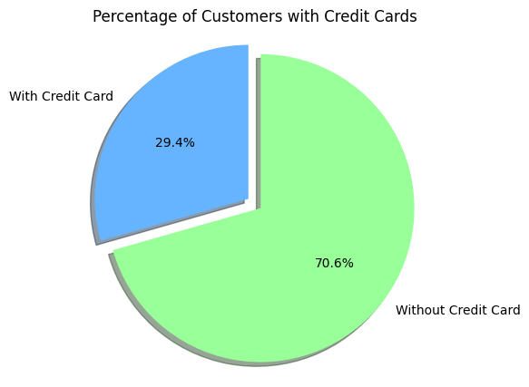

```python
# 2. How many customers have credit cards?
credit_card_count = data['CreditCard'].sum()
total_customers = data.shape[0]
credit_card_no = total_customers - credit_card_count
print(f'Number of customers with credit cards: {credit_card_count}')

# Prepare data for the pie chart
labels = ['With Credit Card', 'Without Credit Card']
sizes = [credit_card_count, credit_card_no]
colors = ['#66b3ff', '#99ff99']
explode = (0.1, 0)  # explode the 'With Credit Card' slice for emphasis

# Plot the pie chart
plt.figure(figsize=(5, 5))
plt.pie(sizes, explode=explode, labels=labels, colors=colors, autopct='%1.1f%%', startangle=90, shadow=True)
plt.title('Percentage of Customers with Credit Cards')
plt.axis('equal')
plt.show()
```

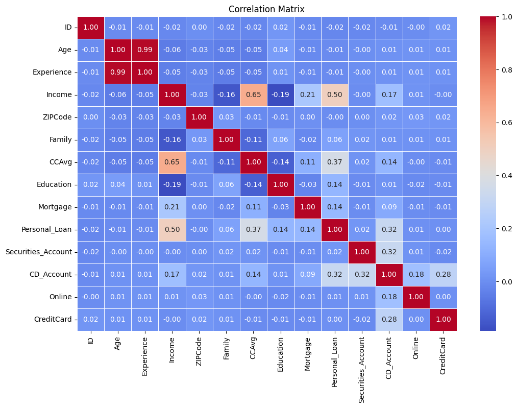

```python
correlation_matrix = data.corr()
plt.figure(figsize=(12, 8))
sns.heatmap(correlation_matrix, annot=True, cmap='coolwarm', fmt='.2f', linewidths=0.5)
plt.title('Correlation Matrix')
plt.show()
```

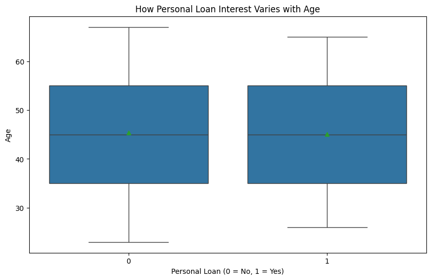

```python
# 4. How does interest in purchasing a loan vary with age?
plt.figure(figsize=(10, 6))
sns.boxplot(data=data, x='Personal_Loan', y='Age', showmeans=True)
plt.title('How Personal Loan Interest Varies with Age')
plt.xlabel('Personal Loan (0 = No, 1 = Yes)')
plt.ylabel('Age')
plt.show()
```

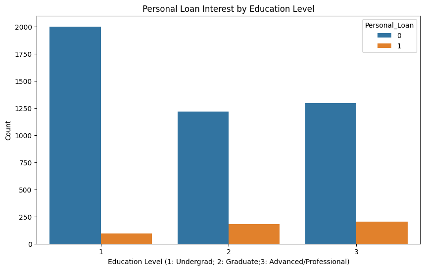

```python
# 5. How does interest in purchasing a loan vary with education?
plt.figure(figsize=(10, 6))
sns.countplot(data=data, x='Education', hue='Personal_Loan')
plt.title('Personal Loan Interest by Education Level')
plt.xlabel('Education Level (1: Undergrad; 2: Graduate;3: Advanced/Professional)')
plt.ylabel('Count')
plt.show()
```

## Data Preprocessing

- Missing value treatment
- Feature engineering (if needed)
- Outlier detection and treatment (if needed)
- Preparing data for modeling
- Any other preprocessing steps (if needed)

**Managing Negative Values in the Experience Column:**

```python
# Count the number of negative values in the "Experience" column
df[df['Experience'] < 0]['Experience'].count()
```

```
52
```

```python
# Filter and display only rows where "Experience" is negative
negative_experience = df[df['Experience'] < 0]

# Display the filtered data with negative values highlighted
styled_negative_experience = negative_experience.style.applymap(
    lambda val: 'color: red' if val < 0 else '', subset=['Experience']
)

# Show the styled DataFrame
styled_negative_experience
```

|  | ID | Age | Experience | Income | ZIPCode | Family | CCAvg | Education | Mortgage | Personal_Loan | Securities_Account | CD_Account | Online | CreditCard |
| --- | --- | --- | --- | --- | --- | --- | --- | --- | --- | --- | --- | --- | --- | --- |
| 89 | 90 | 25 | -1 | 113 | 94303 | 4 | 2.300000 | 3 | 0 | 0 | 0 | 0 | 0 | 1 |
| 226 | 227 | 24 | -1 | 39 | 94085 | 2 | 1.700000 | 2 | 0 | 0 | 0 | 0 | 0 | 0 |
| 315 | 316 | 24 | -2 | 51 | 90630 | 3 | 0.300000 | 3 | 0 | 0 | 0 | 0 | 1 | 0 |
| 451 | 452 | 28 | -2 | 48 | 94132 | 2 | 1.750000 | 3 | 89 | 0 | 0 | 0 | 1 | 0 |
| 524 | 525 | 24 | -1 | 75 | 93014 | 4 | 0.200000 | 1 | 0 | 0 | 0 | 0 | 1 | 0 |
| 536 | 537 | 25 | -1 | 43 | 92173 | 3 | 2.400000 | 2 | 176 | 0 | 0 | 0 | 1 | 0 |
| 540 | 541 | 25 | -1 | 109 | 94010 | 4 | 2.300000 | 3 | 314 | 0 | 0 | 0 | 1 | 0 |
| 576 | 577 | 25 | -1 | 48 | 92870 | 3 | 0.300000 | 3 | 0 | 0 | 0 | 0 | 0 | 1 |
| 583 | 584 | 24 | -1 | 38 | 95045 | 2 | 1.700000 | 2 | 0 | 0 | 0 | 0 | 1 | 0 |
| 597 | 598 | 24 | -2 | 125 | 92835 | 2 | 7.200000 | 1 | 0 | 0 | 1 | 0 | 0 | 1 |
| 649 | 650 | 25 | -1 | 82 | 92677 | 4 | 2.100000 | 3 | 0 | 0 | 0 | 0 | 1 | 0 |
| 670 | 671 | 23 | -1 | 61 | 92374 | 4 | 2.600000 | 1 | 239 | 0 | 0 | 0 | 1 | 0 |
| 686 | 687 | 24 | -1 | 38 | 92612 | 4 | 0.600000 | 2 | 0 | 0 | 0 | 0 | 1 | 0 |
| 793 | 794 | 24 | -2 | 150 | 94720 | 2 | 2.000000 | 1 | 0 | 0 | 0 | 0 | 1 | 0 |
| 889 | 890 | 24 | -2 | 82 | 91103 | 2 | 1.600000 | 3 | 0 | 0 | 0 | 0 | 1 | 1 |
| 909 | 910 | 23 | -1 | 149 | 91709 | 1 | 6.330000 | 1 | 305 | 0 | 0 | 0 | 0 | 1 |
| 1173 | 1174 | 24 | -1 | 35 | 94305 | 2 | 1.700000 | 2 | 0 | 0 | 0 | 0 | 0 | 0 |
| 1428 | 1429 | 25 | -1 | 21 | 94583 | 4 | 0.400000 | 1 | 90 | 0 | 0 | 0 | 1 | 0 |
| 1522 | 1523 | 25 | -1 | 101 | 94720 | 4 | 2.300000 | 3 | 256 | 0 | 0 | 0 | 0 | 1 |
| 1905 | 1906 | 25 | -1 | 112 | 92507 | 2 | 2.000000 | 1 | 241 | 0 | 0 | 0 | 1 | 0 |
| 2102 | 2103 | 25 | -1 | 81 | 92647 | 2 | 1.600000 | 3 | 0 | 0 | 0 | 0 | 1 | 1 |
| 2430 | 2431 | 23 | -1 | 73 | 92120 | 4 | 2.600000 | 1 | 0 | 0 | 0 | 0 | 1 | 0 |
| 2466 | 2467 | 24 | -2 | 80 | 94105 | 2 | 1.600000 | 3 | 0 | 0 | 0 | 0 | 1 | 0 |
| 2545 | 2546 | 25 | -1 | 39 | 94720 | 3 | 2.400000 | 2 | 0 | 0 | 0 | 0 | 1 | 0 |
| 2618 | 2619 | 23 | -3 | 55 | 92704 | 3 | 2.400000 | 2 | 145 | 0 | 0 | 0 | 1 | 0 |
| 2717 | 2718 | 23 | -2 | 45 | 95422 | 4 | 0.600000 | 2 | 0 | 0 | 0 | 0 | 1 | 1 |
| 2848 | 2849 | 24 | -1 | 78 | 94720 | 2 | 1.800000 | 2 | 0 | 0 | 0 | 0 | 0 | 0 |
| 2876 | 2877 | 24 | -2 | 80 | 91107 | 2 | 1.600000 | 3 | 238 | 0 | 0 | 0 | 0 | 0 |
| 2962 | 2963 | 23 | -2 | 81 | 91711 | 2 | 1.800000 | 2 | 0 | 0 | 0 | 0 | 0 | 0 |
| 2980 | 2981 | 25 | -1 | 53 | 94305 | 3 | 2.400000 | 2 | 0 | 0 | 0 | 0 | 0 | 0 |
| 3076 | 3077 | 29 | -1 | 62 | 92672 | 2 | 1.750000 | 3 | 0 | 0 | 0 | 0 | 0 | 1 |
| 3130 | 3131 | 23 | -2 | 82 | 92152 | 2 | 1.800000 | 2 | 0 | 0 | 1 | 0 | 0 | 1 |
| 3157 | 3158 | 23 | -1 | 13 | 94720 | 4 | 1.000000 | 1 | 84 | 0 | 0 | 0 | 1 | 0 |
| 3279 | 3280 | 26 | -1 | 44 | 94901 | 1 | 2.000000 | 2 | 0 | 0 | 0 | 0 | 0 | 0 |
| 3284 | 3285 | 25 | -1 | 101 | 95819 | 4 | 2.100000 | 3 | 0 | 0 | 0 | 0 | 0 | 1 |
| 3292 | 3293 | 25 | -1 | 13 | 95616 | 4 | 0.400000 | 1 | 0 | 0 | 1 | 0 | 0 | 0 |
| 3394 | 3395 | 25 | -1 | 113 | 90089 | 4 | 2.100000 | 3 | 0 | 0 | 0 | 0 | 1 | 0 |
| 3425 | 3426 | 23 | -1 | 12 | 91605 | 4 | 1.000000 | 1 | 90 | 0 | 0 | 0 | 1 | 0 |
| 3626 | 3627 | 24 | -3 | 28 | 90089 | 4 | 1.000000 | 3 | 0 | 0 | 0 | 0 | 0 | 0 |
| 3796 | 3797 | 24 | -2 | 50 | 94920 | 3 | 2.400000 | 2 | 0 | 0 | 1 | 0 | 0 | 0 |
| 3824 | 3825 | 23 | -1 | 12 | 95064 | 4 | 1.000000 | 1 | 0 | 0 | 1 | 0 | 0 | 1 |
| 3887 | 3888 | 24 | -2 | 118 | 92634 | 2 | 7.200000 | 1 | 0 | 0 | 1 | 0 | 1 | 0 |
| 3946 | 3947 | 25 | -1 | 40 | 93117 | 3 | 2.400000 | 2 | 0 | 0 | 0 | 0 | 1 | 0 |
| 4015 | 4016 | 25 | -1 | 139 | 93106 | 2 | 2.000000 | 1 | 0 | 0 | 0 | 0 | 0 | 1 |
| 4088 | 4089 | 29 | -1 | 71 | 94801 | 2 | 1.750000 | 3 | 0 | 0 | 0 | 0 | 0 | 0 |
| 4116 | 4117 | 24 | -2 | 135 | 90065 | 2 | 7.200000 | 1 | 0 | 0 | 0 | 0 | 1 | 0 |
| 4285 | 4286 | 23 | -3 | 149 | 93555 | 2 | 7.200000 | 1 | 0 | 0 | 0 | 0 | 1 | 0 |
| 4411 | 4412 | 23 | -2 | 75 | 90291 | 2 | 1.800000 | 2 | 0 | 0 | 0 | 0 | 1 | 1 |
| 4481 | 4482 | 25 | -2 | 35 | 95045 | 4 | 1.000000 | 3 | 0 | 0 | 0 | 0 | 1 | 0 |
| 4514 | 4515 | 24 | -3 | 41 | 91768 | 4 | 1.000000 | 3 | 0 | 0 | 0 | 0 | 1 | 0 |
| 4582 | 4583 | 25 | -1 | 69 | 92691 | 3 | 0.300000 | 3 | 0 | 0 | 0 | 0 | 1 | 0 |
| 4957 | 4958 | 29 | -1 | 50 | 95842 | 2 | 1.750000 | 3 | 0 | 0 | 0 | 0 | 0 | 1 |

```python
# Convert negative values in "Experience" to positive
data['Experience'] = data['Experience'].abs()

# Count how many negative values are left -->(should be 0)<--
data[data['Experience'] < 0]['Experience'].count()
```

```
np.int64(0)
```

**Observations:**

Negative values in the "Experience" column were likely due to typing errors and have been corrected by converting them to positive values.

**Conversion of Data Types**

```python
# Convert specified columns to 'category' data type for efficient memory usage and processing
category_columns = ['Personal_Loan', 'Securities_Account', 'CD_Account', 'Online', 'CreditCard', 'Education']
data[category_columns] = data[category_columns].astype('category')

# Print the names of the categorical columns that were converted
print('Categorical columns:', category_columns)
```

```
Categorical columns: ['Personal_Loan', 'Securities_Account', 'CD_Account', 'Online', 'CreditCard', 'Education']
```

**Observations:**

The columns Personal_Loan, Securities_Account, CD_Account, Online, CreditCard, and Education are of type int/object in the original dataset, but they represent categorical variables. Therefore, the data types are being converted accordingly.

**Dropping ID column**

```python
# Removing the 'ID' column from the dataset as it is not required
data.drop(columns='ID', axis='columns', inplace=True)
```

```python
# Verify that the 'ID' column has been successfully removed by listing all remaining columns
data.columns
```

```
Index(['Age', 'Experience', 'Income', 'ZIPCode', 'Family', 'CCAvg',
       'Education', 'Mortgage', 'Personal_Loan', 'Securities_Account',
       'CD_Account', 'Online', 'CreditCard'],
      dtype='object')
```

**Observations:**

The ID column is unnecessary and will be removed from the dataset.

**Deriving geographic regions based on ZIP codes.**

```python
# Counting the number of unique ZIP codes in the dataset
len(data.ZIPCode.unique())
```

```
467
```

```python
# Adding a 'county' column based on the ZIP code
data['county'] = data['ZIPCode'].apply(lambda x: search.by_zipcode(x).county)

# Showing the unique counties
data['county'].unique()
```

```
array(['Los Angeles County', 'Alameda County', 'San Francisco County',
       'San Diego County', 'Monterey County', 'Ventura County',
       'Santa Barbara County', 'Marin County', 'Santa Clara County',
       'Santa Cruz County', 'San Mateo County', 'Humboldt County',
       'Contra Costa County', 'Orange County', 'Sacramento County',
       'Yolo County', 'Placer County', 'San Bernardino County',
       'San Luis Obispo County', 'Riverside County', 'Kern County', None,
       'Fresno County', 'Sonoma County', 'El Dorado County',
       'San Benito County', 'Butte County', 'Solano County',
       'Mendocino County', 'San Joaquin County', 'Imperial County',
       'Siskiyou County', 'Merced County', 'Trinity County',
       'Stanislaus County', 'Shasta County', 'Tuolumne County',
       'Napa County', 'Lake County'], dtype=object)
```

```python
# Checking for unmapped ZIP codes where the 'county' is null
data[data['county'].isnull()]['ZIPCode'].unique()
```

```
array([92717, 93077, 92634, 96651])
```

```python
# Update county for specific zip codes
data.loc[data['ZIPCode'].isin([92717, 92634]), 'county'] = 'Orange County'
data.loc[data['ZIPCode'].isin([93077]), 'county'] = '93077'
data.loc[data['ZIPCode'].isin([96651]), 'county'] = '96651'

# Group by county and count occurrences of each ZIPCode
county_counts = data.groupby('county')['ZIPCode'].count().sort_values(ascending=False)

# Display the result
print(county_counts)
```

```
county
Los Angeles County        1095
San Diego County           568
Santa Clara County         563
Alameda County             500
Orange County              366
San Francisco County       257
San Mateo County           204
Sacramento County          184
Santa Barbara County       154
Yolo County                130
Monterey County            128
Ventura County             114
San Bernardino County      101
Contra Costa County         85
Santa Cruz County           68
Riverside County            56
Kern County                 54
Marin County                54
Solano County               33
San Luis Obispo County      33
Humboldt County             32
Sonoma County               28
Fresno County               26
Placer County               24
Butte County                19
Shasta County               18
El Dorado County            17
Stanislaus County           15
San Benito County           14
San Joaquin County          13
Mendocino County             8
Siskiyou County              7
Tuolumne County              7
96651                        6
Merced County                4
Lake County                  4
Trinity County               4
Napa County                  3
Imperial County              3
93077                        1
Name: ZIPCode, dtype: int64
```

```python
# Define the mapping of counties to regions
county_region = {
    'Los Angeles County': 'Los Angeles Region',
    'San Diego County': 'San Diego - Imperial',
    'Santa Clara County': 'San Francisco Bay Area',
    'Alameda County': 'San Francisco Bay Area',
    'Orange County': 'Orange County Area',
    'San Francisco County': 'San Francisco Bay Area',
    'San Mateo County': 'San Francisco Bay Area',
    'Sacramento County': 'Superior California',
    'Santa Barbara County': 'Central Coast',
    'Yolo County': 'Superior California',
    'Monterey County': 'Central Coast',
    'Ventura County': 'Central Coast',
    'San Bernardino County': 'Inland Empire',
    'Contra Costa County': 'San Francisco Bay Area',
    'Santa Cruz County': 'Central Coast',
    'Riverside County': 'Inland Empire',
    'Kern County': 'Southern San Joaquin Valley',
    'Marin County': 'San Francisco Bay Area',
    'San Luis Obispo County': 'Central Coast',
    'Solano County': 'San Francisco Bay Area',
    'Humboldt County': 'North Coast',
    'Sonoma County': 'North Coast',
    'Fresno County': 'Southern San Joaquin Valley',
    'Placer County': 'Superior California',
    'Butte County': 'Superior California',
    'Shasta County': 'Superior California',
    'El Dorado County': 'Superior California',
    'Stanislaus County': 'Northern San Joaquin Valley',
    'San Benito County': 'Central Coast',
    'San Joaquin County': 'Northern San Joaquin Valley',
    'Mendocino County': 'North Coast',
    'Tuolumne County': 'Northern San Joaquin Valley',
    'Siskiyou County': 'Superior California',
    'Trinity County': 'North Coast',
    'Merced County': 'Northern San Joaquin Valley',
    'Lake County': 'North Coast',
    'Napa County': 'North Coast',
    'Imperial County': 'San Diego - Imperial',
    '93077': 'Central Coast',
    '96651': 'Superior California'
}

# Create a new column 'region' by mapping 'county' to 'region' using the county_region dictionary
data['region'] = data['county'].map(county_region).astype('category')

# Convert 'county' and 'region' columns to categorical types to optimize memory usage
data['county'] = data['county'].astype('category')
```

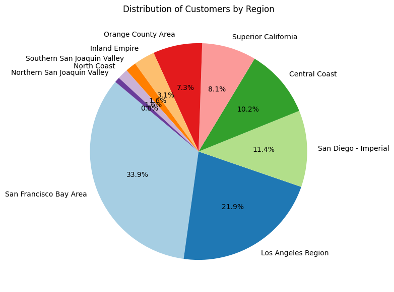

```python
# Count the number of occurrences of each region
region_counts = data['region'].value_counts()

# Create the pie chart
plt.figure(figsize=(10, 7))
plt.pie(region_counts, labels=region_counts.index, autopct='%1.1f%%', startangle=140, colors=plt.cm.Paired.colors)

# Add a title
plt.title('Distribution of Customers by Region')

# Display the pie chart
plt.show()
```

```python
data.dtypes
```

|  | 0 |
| --- | --- |
| Age | int64 |
| Experience | int64 |
| Income | int64 |
| ZIPCode | int64 |
| Family | int64 |
| CCAvg | float64 |
| Education | category |
| Mortgage | int64 |
| Personal_Loan | category |
| Securities_Account | category |
| CD_Account | category |
| Online | category |
| CreditCard | category |
| county | category |
| region | category |

**dtype:** object

**Observation**

We handled unmapped zip codes (92717, 92634, 93077, 96651) by manually assigning them to the appropriate counties. Zip codes 92717 and 92634 were mapped to Orange County, while 93077 was assigned to Central Coast, and 96651 was mapped to Superior California. This ensures all zip codes are properly categorized and allows for region mapping to be completed effectively.

**Outlier Detection and Treatment (if needed)**

```python
# Select only numerical columns for quantile calculation
numerical_data = data.select_dtypes(include=['float64', 'int64'])

# Calculate Q1 (25th percentile) and Q3 (75th percentile) for numerical columns
Q1 = numerical_data.quantile(0.25)
Q3 = numerical_data.quantile(0.75)

# Calculate the IQR
IQR = Q3 - Q1

# Define lower and upper bounds for outliers
lower_bound = Q1 - 1.5 * IQR
upper_bound = Q3 + 1.5 * IQR

# Find the outliers in the numerical columns
outliers_condition = (numerical_data < lower_bound) | (numerical_data > upper_bound)

# Calculate the percentage of outliers in the dataset
outlier_percentage = outliers_condition.sum() / len(data) * 100

# Print the percentage of outliers
print(outlier_percentage)
```

[output not shown]

**Observation:**

Upon analyzing the dataset, we observed that the percentage of outliers in most columns is relatively low, with values such as 'Age', 'Experience', and 'ZIPCode' showing no significant outliers. Although some columns like 'Income', 'CCAvg', and 'Mortgage' contain a small percentage of outliers, it was decided not to treat them at this stage, as their impact on model performance is expected to be minimal.

**Dropping columns**

```python
# Creating a copy of the original data for train-test split
data_train_test = data.copy()
```

```python
data_train_test.head(3)
```

|  | Age | Experience | Income | ZIPCode | Family | CCAvg | Education | Mortgage | Personal_Loan | Securities_Account | CD_Account | Online | CreditCard | county | region |
| --- | --- | --- | --- | --- | --- | --- | --- | --- | --- | --- | --- | --- | --- | --- | --- |
| 0 | 25 | 1 | 49 | 91107 | 4 | 1.6 | 1 | 0 | 0 | 1 | 0 | 0 | 0 | Los Angeles County | Los Angeles Region |
| 1 | 45 | 19 | 34 | 90089 | 3 | 1.5 | 1 | 0 | 0 | 1 | 0 | 0 | 0 | Los Angeles County | Los Angeles Region |
| 2 | 39 | 15 | 11 | 94720 | 1 | 1.0 | 1 | 0 | 0 | 0 | 0 | 0 | 0 | Alameda County | San Francisco Bay Area |

```python
# Dropping the 'county' and 'ZIPCode' columns as they are not required for model training
data_train_test.drop(columns=['county', 'ZIPCode'], inplace=True)

data_train_test.head(3)
```

|  | Age | Experience | Income | Family | CCAvg | Education | Mortgage | Personal_Loan | Securities_Account | CD_Account | Online | CreditCard | region |
| --- | --- | --- | --- | --- | --- | --- | --- | --- | --- | --- | --- | --- | --- |
| 0 | 25 | 1 | 49 | 4 | 1.6 | 1 | 0 | 0 | 1 | 0 | 0 | 0 | Los Angeles Region |
| 1 | 45 | 19 | 34 | 3 | 1.5 | 1 | 0 | 0 | 1 | 0 | 0 | 0 | Los Angeles Region |
| 2 | 39 | 15 | 11 | 1 | 1.0 | 1 | 0 | 0 | 0 | 0 | 0 | 0 | San Francisco Bay Area |

**Observation:**

Dropping 'county' and 'ZIPCode' columns as they are not needed for model training, using 'region' instead

**Creating training and testing datasets**

```python
# Dropping Experience as it is perfectly correlated with Age
X = data_train_test.drop(["Personal_Loan", "Experience"], axis=1)
y = data_train_test["Personal_Loan"]

# One-hot encoding categorical variables (Education and Region)
X = pd.get_dummies(X, columns=['Education', 'region'], drop_first=True)

# Converting all features in X to float type to ensure compatibility with machine learning models
X = X.astype(float)

# Splitting data into train and test sets (70% training, 30% testing)
X_train, X_test, y_train, y_test = train_test_split(
    X, y, test_size=0.30, random_state=42)
```

```python
print('Shape of Training set : ',X_train.shape )
print('Shape of test set : ',X_test.shape )
print('Percentage of classes in training set:\n',y_train.value_counts(normalize=True)*100)
print('Percentage of classes in test set:\n',y_test.value_counts(normalize=True)*100)
```

```
Shape of Training set :  (3500, 20)
Shape of test set :  (1500, 20)
Percentage of classes in training set:
 Personal_Loan
0    90.771429
1     9.228571
Name: proportion, dtype: float64
Percentage of classes in test set:
 Personal_Loan
0    89.533333
1    10.466667
Name: proportion, dtype: float64
```

## Model Building

### Model Evaluation Criterion

**Model Evaluation Criteria:**

The model can make two types of wrong predictions:

False Positive (FP): Predicting that a person will buy a loan when they actually don't.

Impact: This results in wasted resources, such as marketing or sales efforts directed at customers who are not interested, potentially reducing the campaign’s efficiency.

False Negative (FN): Predicting that a person will not buy a loan, but they actually do.

Impact: This leads to a loss of opportunity, as the marketing and sales team fail to engage with potential customers who could have become buyers, undermining the campaign's success.

### Model Building

**Model Performance Evaluation: Scoring and Confusion Matrix**

```python
def evaluate_classification_model(model, X, y):
    """
    Function to evaluate the performance of a classification model using various metrics.

    Parameters:
    - model: Trained classifier model
    - X: Independent variables (features)
    - y: True labels (target variable)

    Returns:
    - A DataFrame containing the evaluation metrics (Accuracy, Recall, Precision, F1).
    """
    # Make predictions using the provided model
    y_pred = model.predict(X)

    # Calculate performance metrics
    accuracy = accuracy_score(y, y_pred)      # Accuracy metric
    recall = recall_score(y, y_pred)          # Recall metric
    precision = precision_score(y, y_pred)   # Precision metric
    f1 = f1_score(y, y_pred)                  # F1-score metric

    # Create a DataFrame to store the metrics
    metrics_df = pd.DataFrame(
        {"Accuracy": [accuracy], "Recall": [recall], "Precision": [precision], "F1": [f1]}
    )

    return metrics_df
```

```python
def make_confusion_matrix(model, X, y, ax=None):
    """
    Function to plot the confusion matrix with percentages.

    Parameters:
    - model: Trained classifier model
    - X: Independent variables (features)
    - y: True labels (target variable)
    - ax: Matplotlib axis (optional, default is None)

    If 'ax' is provided, the plot will be drawn on the given axis.
    Otherwise, a new axis will be created.
    """
    # Predict the target variable using the model
    y_pred = model.predict(X)

    # Generate the confusion matrix
    cm = confusion_matrix(y, y_pred)

    # Prepare labels with percentages for display
    labels = np.asarray(
        [["{0:0.0f}\n{1:.2%}".format(item, item / cm.sum())] for item in cm.flatten()]
    ).reshape(cm.shape)

    # If no axis is provided, create a new one
    if ax is None:
        fig, ax = plt.subplots(figsize=(6, 4))

    # Create the heatmap using seaborn
    sns.heatmap(cm, annot=labels, fmt="", cmap="Blues", ax=ax, cbar=False)

    # Set axis labels and title
    ax.set_ylabel("True Label")
    ax.set_xlabel("Predicted Label")
    ax.set_title("Confusion Matrix")
```

**Building a Decision Tree Model**

```python
model = DecisionTreeClassifier(criterion="gini", random_state=1)
model.fit(X_train, y_train)
```

```
DecisionTreeClassifier(random_state=1)
```

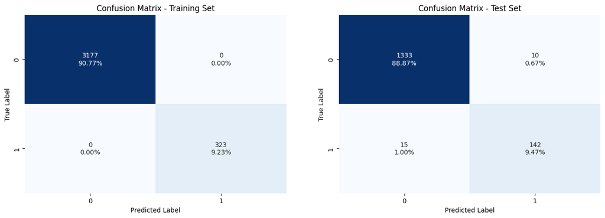

```python
fig, axes = plt.subplots(1, 2, figsize=(16, 5))

# Train set
make_confusion_matrix(model, X_train, y_train, ax=axes[0])
axes[0].set_title("Confusion Matrix - Training Set")

# Test set
make_confusion_matrix(model, X_test, y_test, ax=axes[1])
axes[1].set_title("Confusion Matrix - Test Set")

plt.show()
```

```python
evaluate_classification_model(model, X_train, y_train)
```

|  | Accuracy | Recall | Precision | F1 |
| --- | --- | --- | --- | --- |
| 0 | 1.0 | 1.0 | 1.0 | 1.0 |

```python
evaluate_classification_model(model, X_test, y_test)
```

|  | Accuracy | Recall | Precision | F1 |
| --- | --- | --- | --- | --- |
| 0 | 0.983333 | 0.904459 | 0.934211 | 0.919094 |

```python
feature_names = list(X.columns)
print(feature_names)
```

[output not shown]

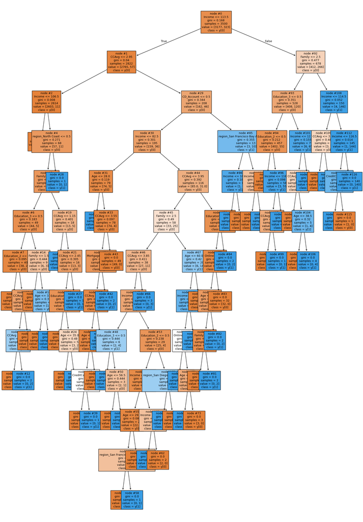

```python
plt.figure(figsize=(20,30))
out = tree.plot_tree(model,feature_names=feature_names,filled=True,fontsize=9,node_ids=True,class_names=True)
for o in out:
     arrow = o.arrow_patch
     if arrow is not None:
        arrow.set_edgecolor('black')
        arrow.set_linewidth(1)
plt.show()
```

```python
# Text report showing the rules of a decision tree -
print(tree.export_text(model,feature_names=feature_names,show_weights=True))
```

```
|--- Income <= 113.50
|   |--- CCAvg <= 2.95
|   |   |--- Income <= 106.50
|   |   |   |--- weights: [2546.00, 0.00] class: 0
|   |   |--- Income >  106.50
|   |   |   |--- region_North Coast <= 0.50
|   |   |   |   |--- Family <= 3.50
|   |   |   |   |   |--- Education_3 <= 0.50
|   |   |   |   |   |   |--- Education_2 <= 0.50
|   |   |   |   |   |   |   |--- weights: [30.00, 0.00] class: 0
|   |   |   |   |   |   |--- Education_2 >  0.50
|   |   |   |   |   |   |   |--- CCAvg <= 1.70
|   |   |   |   |   |   |   |   |--- CCAvg <= 0.95
|   |   |   |   |   |   |   |   |   |--- weights: [1.00, 0.00] class: 0
|   |   |   |   |   |   |   |   |--- CCAvg >  0.95
|   |   |   |   |   |   |   |   |   |--- weights: [0.00, 2.00] class: 1
|   |   |   |   |   |   |   |--- CCAvg >  1.70
|   |   |   |   |   |   |   |   |--- weights: [7.00, 0.00] class: 0
|   |   |   |   |   |--- Education_3 >  0.50
|   |   |   |   |   |   |--- Family <= 1.50
|   |   |   |   |   |   |   |--- weights: [5.00, 0.00] class: 0
|   |   |   |   |   |   |--- Family >  1.50
|   |   |   |   |   |   |   |--- Age <= 33.50
|   |   |   |   |   |   |   |   |--- weights: [1.00, 0.00] class: 0
|   |   |   |   |   |   |   |--- Age >  33.50
|   |   |   |   |   |   |   |   |--- weights: [0.00, 3.00] class: 1
|   |   |   |   |--- Family >  3.50
|   |   |   |   |   |--- CCAvg <= 1.15
|   |   |   |   |   |   |--- weights: [0.00, 2.00] class: 1
|   |   |   |   |   |--- CCAvg >  1.15
|   |   |   |   |   |   |--- CCAvg <= 2.45
|   |   |   |   |   |   |   |--- Education_2 <= 0.50
|   |   |   |   |   |   |   |   |--- weights: [10.00, 0.00] class: 0
|   |   |   |   |   |   |   |--- Education_2 >  0.50
|   |   |   |   |   |   |   |   |--- Age <= 35.00
|   |   |   |   |   |   |   |   |   |--- weights: [3.00, 0.00] class: 0
|   |   |   |   |   |   |   |   |--- Age >  35.00
|   |   |   |   |   |   |   |   |   |--- weights: [0.00, 2.00] class: 1
|   |   |   |   |   |   |--- CCAvg >  2.45
|   |   |   |   |   |   |   |--- weights: [0.00, 1.00] class: 1
```

[output cut: 117 more lines]

```
|   |   |   |   |--- weights: [0.00, 61.00] class: 1
|   |--- Family >  2.50
|   |   |--- Income <= 114.50
|   |   |   |--- CCAvg <= 3.45
|   |   |   |   |--- weights: [3.00, 0.00] class: 0
|   |   |   |--- CCAvg >  3.45
|   |   |   |   |--- weights: [0.00, 2.00] class: 1
|   |   |--- Income >  114.50
|   |   |   |--- Income <= 116.50
|   |   |   |   |--- CreditCard <= 0.50
|   |   |   |   |   |--- weights: [0.00, 4.00] class: 1
|   |   |   |   |--- CreditCard >  0.50
|   |   |   |   |   |--- weights: [1.00, 0.00] class: 0
|   |   |   |--- Income >  116.50
|   |   |   |   |--- weights: [0.00, 140.00] class: 1
```

```python
# importance of features in the tree building ( The importance of a feature is computed as the
# (normalized) total reduction of the criterion brought by that feature. It is also known as the Gini importance )

print(
    pd.DataFrame(
        model.feature_importances_, columns=["Imp"], index=X_train.columns
    ).sort_values(by="Imp", ascending=False)
)
```

```
                                         Imp
Income                              0.311362
Family                              0.241148
Education_2                         0.167023
Education_3                         0.136805
CCAvg                               0.075340
Age                                 0.030872
CD_Account                          0.014207
Mortgage                            0.005445
region_San Francisco Bay Area       0.004801
CreditCard                          0.004434
Online                              0.003857
region_North Coast                  0.002432
region_San Diego - Imperial         0.002274
Securities_Account                  0.000000
region_Inland Empire                0.000000
region_Los Angeles Region           0.000000
region_Orange County Area           0.000000
region_Northern San Joaquin Valley  0.000000
region_Southern San Joaquin Valley  0.000000
region_Superior California          0.000000
```

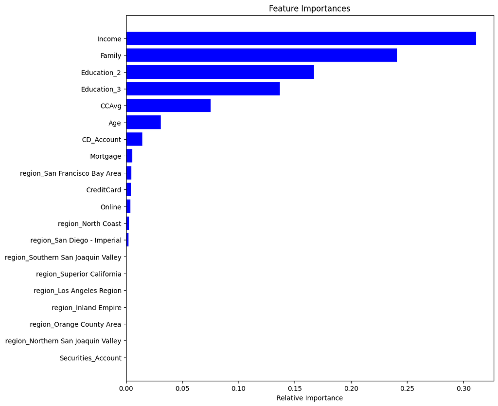

```python
# Get feature importance values from the trained model
importances = model.feature_importances_

# Get sorted indices of features based on importance (ascending order)
indices = np.argsort(importances)

# Set figure size for better visualization
plt.figure(figsize=(10, 10))

# Set plot title
plt.title('Feature Importances')

# Plot horizontal bar chart of feature importances
plt.barh(range(len(indices)), importances[indices], color='blue', align='center')

# Label the y-axis with feature names in the sorted order
plt.yticks(range(len(indices)), [feature_names[i] for i in indices])

# Label the x-axis to indicate relative importance
plt.xlabel('Relative Importance')

# Display the plot
plt.show()
```

**Observation:**

The model identifies Income as the most influential feature, followed by Family Size and Education Level. However, the Decision Tree appears to be overly complex, leading to overfitting. This is evident as the model achieves 100% accuracy on the training set, while on the test set, the recall is 90%, indicating a slight drop in generalization performance.

## Model Performance Improvement

**Pre-Pruning (Setting Constraints During Training)**

```python
param_grid = {
    'max_depth': np.arange(1, 13),  # Fix: Provide a valid range
    'min_samples_split': [10, 30, 50, 70],  # Fix: Correct parameter name
    'max_leaf_nodes': [5, 10, 15, 20, 25, 30, 50],
}

dt = DecisionTreeClassifier(random_state=42)
grid_search = GridSearchCV(dt, param_grid, cv=5, scoring="accuracy", n_jobs=-1)
grid_search.fit(X_train, y_train)

# Best pre-pruned model
best_pre_pruned = grid_search.best_estimator_

# Print the best hyperparameters
print("Best Hyperparameters:", grid_search.best_params_)
```

```
Best Hyperparameters: {'max_depth': np.int64(10), 'max_leaf_nodes': 20, 'min_samples_split': 10}
```

**Checking performance on test data**

```python
evaluate_classification_model(best_pre_pruned, X_train, y_train)
```

|  | Accuracy | Recall | Precision | F1 |
| --- | --- | --- | --- | --- |
| 0 | 0.989429 | 0.907121 | 0.976667 | 0.94061 |

```python
evaluate_classification_model(best_pre_pruned, X_test, y_test)
```

|  | Accuracy | Recall | Precision | F1 |
| --- | --- | --- | --- | --- |
| 0 | 0.985333 | 0.898089 | 0.959184 | 0.927632 |

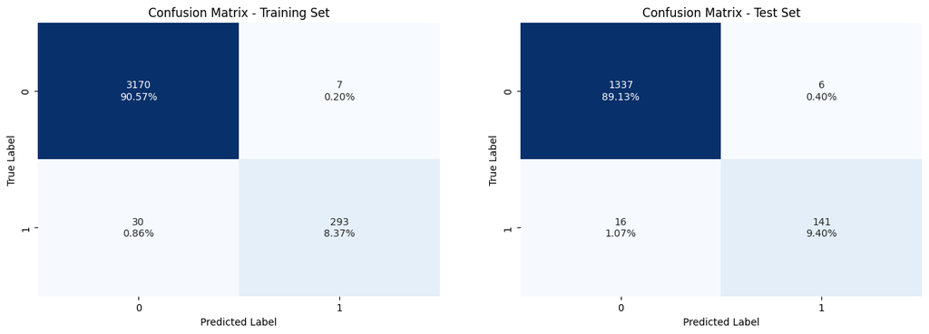

```python
fig, axes = plt.subplots(1, 2, figsize=(16, 5))

# Train set
make_confusion_matrix(best_pre_pruned, X_train, y_train, ax=axes[0])
axes[0].set_title("Confusion Matrix - Training Set")

# Test set
make_confusion_matrix(best_pre_pruned, X_test, y_test, ax=axes[1])
axes[1].set_title("Confusion Matrix - Test Set")

plt.show()
```

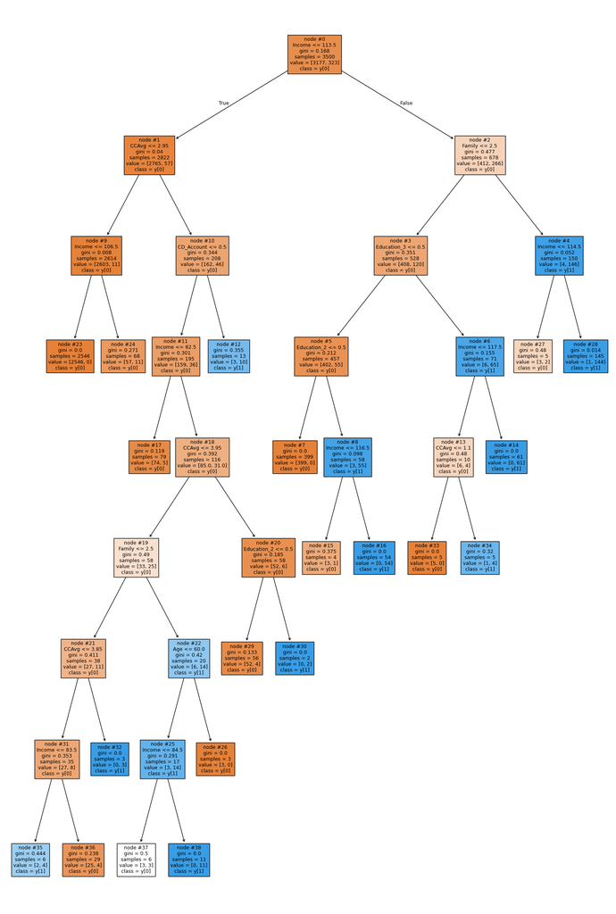

```python
plt.figure(figsize=(20,30))
out = tree.plot_tree(best_pre_pruned,feature_names=feature_names,filled=True,fontsize=9,node_ids=True,class_names=True)
for o in out:
     arrow = o.arrow_patch
     if arrow is not None:
        arrow.set_edgecolor('black')
        arrow.set_linewidth(1)
plt.show()
```

```python
# Text report showing the rules of a decision tree -
print(tree.export_text(best_pre_pruned,feature_names=feature_names,show_weights=True))
```

```
|--- Income <= 113.50
|   |--- CCAvg <= 2.95
|   |   |--- Income <= 106.50
|   |   |   |--- weights: [2546.00, 0.00] class: 0
|   |   |--- Income >  106.50
|   |   |   |--- weights: [57.00, 11.00] class: 0
|   |--- CCAvg >  2.95
|   |   |--- CD_Account <= 0.50
|   |   |   |--- Income <= 82.50
|   |   |   |   |--- weights: [74.00, 5.00] class: 0
|   |   |   |--- Income >  82.50
|   |   |   |   |--- CCAvg <= 3.95
|   |   |   |   |   |--- Family <= 2.50
|   |   |   |   |   |   |--- CCAvg <= 3.85
|   |   |   |   |   |   |   |--- Income <= 83.50
|   |   |   |   |   |   |   |   |--- weights: [2.00, 4.00] class: 1
|   |   |   |   |   |   |   |--- Income >  83.50
|   |   |   |   |   |   |   |   |--- weights: [25.00, 4.00] class: 0
|   |   |   |   |   |   |--- CCAvg >  3.85
|   |   |   |   |   |   |   |--- weights: [0.00, 3.00] class: 1
|   |   |   |   |   |--- Family >  2.50
|   |   |   |   |   |   |--- Age <= 60.00
|   |   |   |   |   |   |   |--- Income <= 84.50
|   |   |   |   |   |   |   |   |--- weights: [3.00, 3.00] class: 0
|   |   |   |   |   |   |   |--- Income >  84.50
|   |   |   |   |   |   |   |   |--- weights: [0.00, 11.00] class: 1
|   |   |   |   |   |   |--- Age >  60.00
|   |   |   |   |   |   |   |--- weights: [3.00, 0.00] class: 0
|   |   |   |   |--- CCAvg >  3.95
|   |   |   |   |   |--- Education_2 <= 0.50
|   |   |   |   |   |   |--- weights: [52.00, 4.00] class: 0
|   |   |   |   |   |--- Education_2 >  0.50
|   |   |   |   |   |   |--- weights: [0.00, 2.00] class: 1
|   |   |--- CD_Account >  0.50
|   |   |   |--- weights: [3.00, 10.00] class: 1
|--- Income >  113.50
|   |--- Family <= 2.50
|   |   |--- Education_3 <= 0.50
|   |   |   |--- Education_2 <= 0.50
|   |   |   |   |--- weights: [399.00, 0.00] class: 0
|   |   |   |--- Education_2 >  0.50
|   |   |   |   |--- Income <= 116.50
|   |   |   |   |   |--- weights: [3.00, 1.00] class: 0
|   |   |   |   |--- Income >  116.50
|   |   |   |   |   |--- weights: [0.00, 54.00] class: 1
|   |   |--- Education_3 >  0.50
|   |   |   |--- Income <= 117.50
|   |   |   |   |--- CCAvg <= 1.10
|   |   |   |   |   |--- weights: [5.00, 0.00] class: 0
|   |   |   |   |--- CCAvg >  1.10
|   |   |   |   |   |--- weights: [1.00, 4.00] class: 1
|   |   |   |--- Income >  117.50
|   |   |   |   |--- weights: [0.00, 61.00] class: 1
|   |--- Family >  2.50
|   |   |--- Income <= 114.50
|   |   |   |--- weights: [3.00, 2.00] class: 0
|   |   |--- Income >  114.50
|   |   |   |--- weights: [1.00, 144.00] class: 1
```

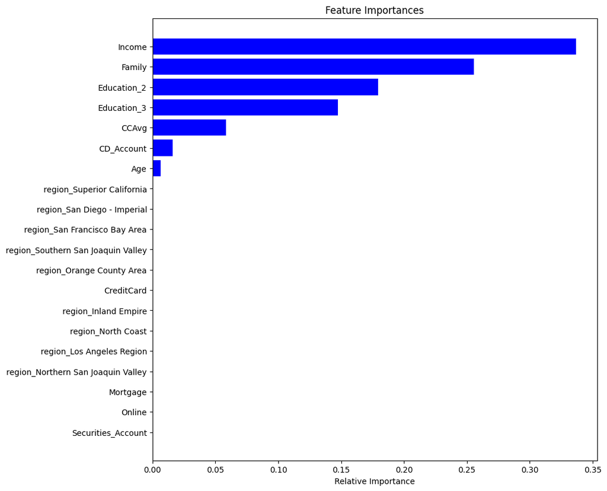

```python
# Get feature importance values from the trained model
importances = best_pre_pruned.feature_importances_

# Get sorted indices of features based on importance (ascending order)
indices = np.argsort(importances)

# Set figure size for better visualization
plt.figure(figsize=(10, 10))

# Set plot title
plt.title('Feature Importances')

# Plot horizontal bar chart of feature importances
plt.barh(range(len(indices)), importances[indices], color='blue', align='center')

# Label the y-axis with feature names in the sorted order
plt.yticks(range(len(indices)), [feature_names[i] for i in indices])

# Label the x-axis to indicate relative importance
plt.xlabel('Relative Importance')

# Display the plot
plt.show()
```

**Obeservation**:

The model identifies Income as the most significant feature, followed by Family Size and Education Level. It is a simplified Decision Tree that maintains a test recall of 89%, indicating strong predictive performance. Additionally, the model shows no signs of overfitting, ensuring better generalization to unseen data.

**Post-Pruning (Cost Complexity Pruning)**

Post-pruning is done by pruning the tree based on cost-complexity pruning (ccp_alpha), which controls complexity by penalizing leaf nodes with little gain.

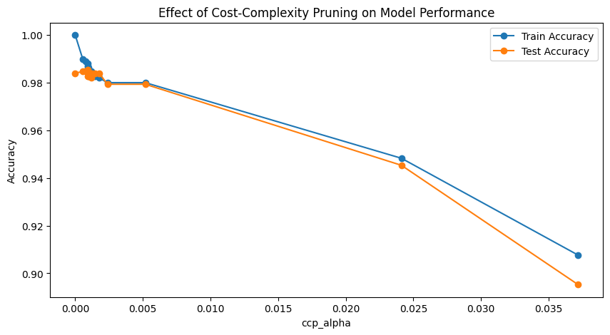

```python
path = best_pre_pruned.cost_complexity_pruning_path(X_train, y_train)
ccp_alphas, impurities = path.ccp_alphas, path.impurities

# Train multiple trees with different ccp_alpha values
pruned_models = []
train_scores = []
test_scores = []

for alpha in ccp_alphas[:-1]:  # Exclude last alpha that prunes the entire tree
    pruned_tree = DecisionTreeClassifier(random_state=42, ccp_alpha=alpha)
    pruned_tree.fit(X_train, y_train)
    pruned_models.append(pruned_tree)

    # Store performance metrics
    train_scores.append(pruned_tree.score(X_train, y_train))
    test_scores.append(pruned_tree.score(X_test, y_test))

# Plot pruning effect
plt.figure(figsize=(10, 5))
plt.plot(ccp_alphas[:-1], train_scores, label="Train Accuracy", marker='o')
plt.plot(ccp_alphas[:-1], test_scores, label="Test Accuracy", marker='o')
plt.xlabel("ccp_alpha")
plt.ylabel("Accuracy")
plt.legend()
plt.title("Effect of Cost-Complexity Pruning on Model Performance")
plt.show()
```

```python
# Select the best ccp_alpha (where test accuracy stabilizes, not peaks)
best_alpha_idx = np.argmax(test_scores)  # Could be optimized by using F1-score
best_ccp_alpha = ccp_alphas[best_alpha_idx]

# Train the final pruned model
final_model = DecisionTreeClassifier(random_state=42, ccp_alpha=best_ccp_alpha)
final_model.fit(X_train, y_train)
```

```
DecisionTreeClassifier(ccp_alpha=np.float64(0.0009142857142857144),
                       random_state=42)
```

```python
# Evaluate model
print("Final Model Performance on Train Data:")
print(classification_report(y_train, final_model.predict(X_train)))

print("Final Model Performance on Test Data:")
print(classification_report(y_test, final_model.predict(X_test)))
```

```
Final Model Performance on Train Data:
              precision    recall  f1-score   support

           0       0.99      1.00      0.99      3177
           1       0.98      0.89      0.93       323

    accuracy                           0.99      3500
   macro avg       0.98      0.94      0.96      3500
weighted avg       0.99      0.99      0.99      3500

Final Model Performance on Test Data:
              precision    recall  f1-score   support

           0       0.99      1.00      0.99      1343
           1       0.96      0.90      0.93       157

    accuracy                           0.99      1500
   macro avg       0.97      0.95      0.96      1500
weighted avg       0.99      0.99      0.99      1500
```

```python
evaluate_classification_model(final_model, X_train, y_train)
```

[output not shown]

```python
evaluate_classification_model(final_model, X_test, y_test)
```

[output not shown]

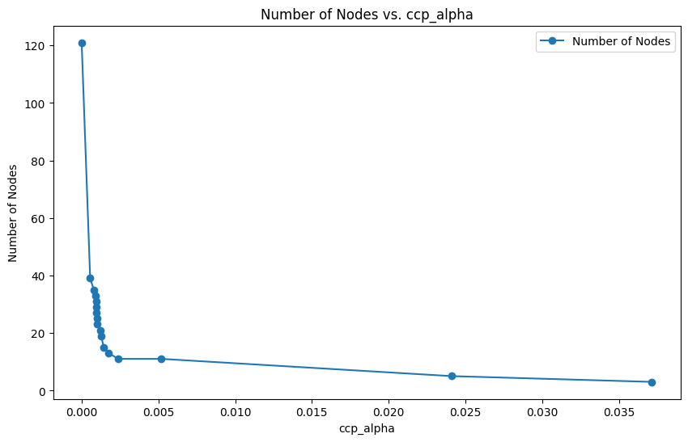

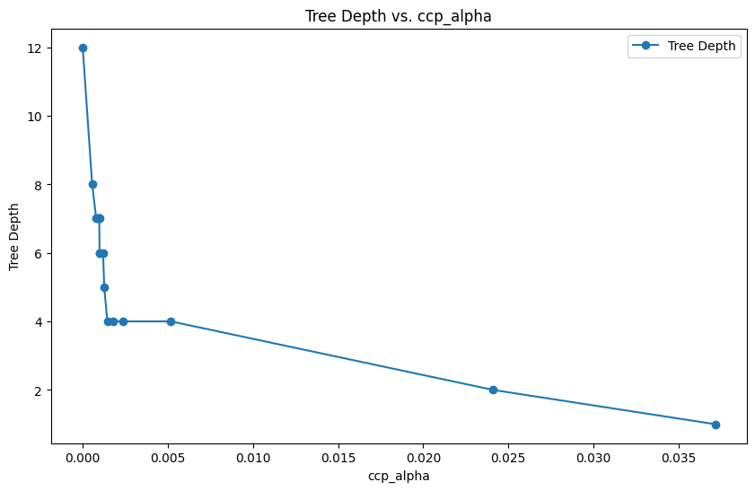

```python
# Track and plot the number of nodes & depth as alpha increases
node_counts = [tree.tree_.node_count for tree in pruned_models]
depths = [tree.tree_.max_depth for tree in pruned_models]

# Plot number of nodes vs. ccp_alpha
plt.figure(figsize=(10, 6))
plt.plot(ccp_alphas[:-1], node_counts, marker='o', label="Number of Nodes")
plt.xlabel("ccp_alpha")
plt.ylabel("Number of Nodes")
plt.title("Number of Nodes vs. ccp_alpha")
plt.legend()
plt.show()

# Plot tree depth vs. ccp_alpha
plt.figure(figsize=(10, 6))
plt.plot(ccp_alphas[:-1], depths, marker='o', label="Tree Depth")
plt.xlabel("ccp_alpha")
plt.ylabel("Tree Depth")
plt.title("Tree Depth vs. ccp_alpha")
plt.legend()
plt.show()
```

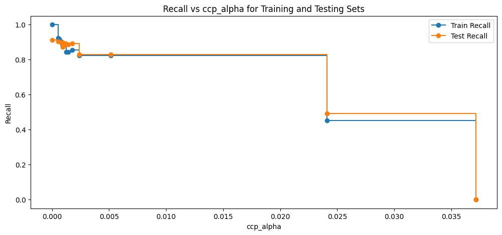

```
Best model found with ccp_alpha = 0.0
```

```
DecisionTreeClassifier(ccp_alpha=np.float64(0.0005546218487394959),
                       random_state=1)
```

```python
# Calculate recall for training and testing sets using pruned models
recall_train_set = []
recall_test_set = []

for clf in pruned_models:
    pred_train = clf.predict(X_train)
    pred_test = clf.predict(X_test)

    recall_train_set.append(recall_score(y_train, pred_train))
    recall_test_set.append(recall_score(y_test, pred_test))

# Adjusted ccp_alphas to match the models used (exclude the last ccp_alpha)
ccp_alphas_adjusted = ccp_alphas[:-1]

# Ensure consistent lengths
assert len(ccp_alphas_adjusted) == len(recall_train_set) == len(recall_test_set), \
    f"Mismatch in lengths: {len(ccp_alphas_adjusted)}, {len(recall_train_set)}, {len(recall_test_set)}"

# Plot Recall vs alpha for training and testing sets
fig, ax = plt.subplots(figsize=(12, 5))
ax.set_xlabel("ccp_alpha")
ax.set_ylabel("Recall")
ax.set_title("Recall vs ccp_alpha for Training and Testing Sets")
ax.plot(ccp_alphas_adjusted, recall_train_set, marker="o", label="Train Recall", drawstyle="steps-post")
ax.plot(ccp_alphas_adjusted, recall_test_set, marker="o", label="Test Recall", drawstyle="steps-post")
ax.legend()
plt.show()

# Select the best model based on recall while preventing overfitting
best_model_index = np.argmax(recall_test_set)  # Chooses the highest test recall
best_ccp_alpha = ccp_alphas_adjusted[best_model_index]

# Print the best ccp_alpha
print(f"Best model found with ccp_alpha = {best_ccp_alpha}")


# Ensure test recall is high while avoiding a large gap from training recall
gap_threshold = 0.05
for i, alpha in enumerate(ccp_alphas_adjusted):
    if abs(recall_train_set[i] - recall_test_set[i]) <= gap_threshold:
        best_ccp_alpha = alpha
        best_model_index = i
        break  # Stop at the first acceptable model

# Train the final selected model
final_model = DecisionTreeClassifier(ccp_alpha=best_ccp_alpha, random_state=1)
final_model.fit(X_train, y_train)
```

```python
evaluate_classification_model(final_model, X_train, y_train)
```

|  | Accuracy | Recall | Precision | F1 |
| --- | --- | --- | --- | --- |
| 0 | 0.991143 | 0.934985 | 0.967949 | 0.951181 |

```python
evaluate_classification_model(final_model, X_test, y_test)
```

|  | Accuracy | Recall | Precision | F1 |
| --- | --- | --- | --- | --- |
| 0 | 0.985333 | 0.910828 | 0.94702 | 0.928571 |

## Model Performance Comparison and Final Model Selection

```python
# testing performance

models = {
    "best_pre_pruned": best_pre_pruned,  # Pre-pruned best model
    "final_model": final_model,  # Final selected model
}

# Initialize a dictionary to store the evaluation results
results = {}

# Loop through the models to evaluate each one
for model_name, model in models.items():
    # Train the model (if not already trained)
    model.fit(X_train, y_train)

    # Call the function to evaluate the model
    metrics_df = evaluate_classification_model(model, X_test, y_test)

    # Store the results in the dictionary
    results[model_name] = metrics_df

    # Print the evaluation metrics for the current model
    print(f"\nModel: {model_name}")
    print(metrics_df)
```

```
Model: best_pre_pruned
   Accuracy    Recall  Precision        F1
0  0.985333  0.898089   0.959184  0.927632

Model: final_model
   Accuracy    Recall  Precision        F1
0  0.985333  0.910828    0.94702  0.928571
```

```python
# training performance

models = {
    "best_pre_pruned": best_pre_pruned,  # Pre-pruned best model
    "final_model": final_model,  # Final selected model
}

# Initialize a dictionary to store the evaluation results
results = {}

# Loop through the models to evaluate each one
for model_name, model in models.items():
    # Train the model (if not already trained)
    model.fit(X_train, y_train)

    # Call the function to evaluate the model on the training set
    metrics_df = evaluate_classification_model(model, X_train, y_train)

    # Store the results in the dictionary
    results[model_name] = metrics_df

    # Print the evaluation metrics for the current model
    print(f"\nModel: {model_name}")
    print(metrics_df)
```

```
Model: best_pre_pruned
   Accuracy    Recall  Precision       F1
0  0.989429  0.907121   0.976667  0.94061

Model: final_model
   Accuracy    Recall  Precision        F1
0  0.991143  0.934985   0.967949  0.951181
```

**Observation:**

**Pre-Pruning**

- The best pre-pruned model had 98.9% accuracy, slightly lower recall than the final model.

**Post-Pruning (Cost-Complexity Pruning)**

- Cost complexity pruning (ccp_alpha) was used to reduce model complexity and generalization errors.
- A tradeoff between training accuracy and test performance was visualized.

## Actionable Insights and Business Recommendations

**Key Insights**

**Income is the Most Influential Factor**

- Higher-income customers are more likely to accept personal loans.
- Customers with an annual income above a certain threshold have a significantly higher likelihood of purchasing loans.

**Family Size and Education Matter**

- Customers with larger families (3 or more members) show a higher tendency to take personal loans.
- Highly educated customers (Graduate & Advanced degrees) are more inclined to take loans compared to undergraduates.

**Credit Card Spending is a Strong Indicator**

- Customers with higher credit card spending (CCAvg) tend to accept personal loans more often.
- The average monthly spending threshold can be a key marketing segmentation metric.

**Existing Banking Relationships Play a Role**

**Business Recommendations**

**Target High-Income Customers with Personalized Offers**

- Focus marketing efforts on customers earning above the identified income threshold.
- Offer them exclusive loan products with personalized interest rates.

**Create Family-Based Loan Offers**

- Design loan products with family-friendly incentives (e.g., lower interest rates for customers with 3+ family members).
- Run promotional campaigns targeting middle-aged customers with families.

**Leverage Credit Card Spending Data for Loan Marketing**

- Identify customers with higher monthly credit card spending and target them for personal loan offers.
- Offer credit card-linked personal loans with better terms.

**Upsell to Certificate of Deposit (CD) Account Holders**

- Since CD account holders are more likely to take loans, create CD-backed personal loans with lower interest rates.
- Market personal loans as a wealth management strategy for CD customers.